# MANOVA

17 oct 2019

## Inhoud

## MANOVA

## MANOVA

Multivariate analysis of variance. We are looking for the multivariate signal to noise ratio. It is used to measure the effects of an independent variable on two or more dependent variables that measure the same construct.

### Independent one-way MANOVA

- Two or more dependent/outcome variables
- One independent/predictor variable
  - Two ore more levels/factors

## Assumptions

- Same as ANOVA’s
- Multivariate normality (not in SPSS)
- Homogeneity of covariance matrices:
  - Box’s test
    - p > .05 good
    - p < .05 not good

## Example

We will use the data from Field’s chapter 16 about behavioural and cognitive neurosis.

Effect of:

- Cognitive behaviour therapy (CBT)
- Behaviour therapy (BT)
- Control

Obsessive compulsive disorder (OCD):

- Obsession-related behaviours (Actions)
- Obsession-related cognitions (Thoughts)

## Data

Let’s load the data and have a look.

| group | actions | thoughts |
| --- | --- | --- |
| Cognitive behaviour therapy | 5 | 14 |
| Cognitive behaviour therapy | 5 | 11 |
| Cognitive behaviour therapy | 4 | 16 |
| Cognitive behaviour therapy | 4 | 13 |
| Cognitive behaviour therapy | 5 | 12 |
| Cognitive behaviour therapy | 3 | 14 |
| Cognitive behaviour therapy | 7 | 12 |
| Cognitive behaviour therapy | 6 | 15 |
| Cognitive behaviour therapy | 6 | 16 |
| Cognitive behaviour therapy | 4 | 11 |

[output cut: 20 more lines]

## Sums of squares

Fist we have to calculate the sums of squares for the model and the error for both variates, actions and thoughts.

Let’s first get some of the means we need for our calculations

```r
aggregate(. ~ group, data, function(x) c(mn =mean(x), n=length(x) ))
```

```
##                         group actions.mn actions.n thoughts.mn thoughts.n
## 1           Behaviour therapy        3.7      10.0        15.2       10.0
## 2 Cognitive behaviour therapy        4.9      10.0        13.4       10.0
## 3                no treatment        5.0      10.0        15.0       10.0
```

```r
thoughts = data$thoughts
actions  = data$actions

m.tho = mean(thoughts)
m.act = mean(actions)

n.tho = length(thoughts)
n.act = length(actions)
```

## And more means

```r
cbt.tho = subset(data, group == "Cognitive behaviour therapy", select="thoughts")$thoughts
bet.tho = subset(data, group == "Behaviour therapy",            select="thoughts")$thoughts
con.tho = subset(data, group == "no treatment",              select="thoughts")$thoughts

cbt.act = subset(data, group == "Cognitive behaviour therapy", select="actions")$actions
bet.act = subset(data, group == "Behaviour therapy",            select="actions")$actions
con.act = subset(data, group == "no treatment",              select="actions")$actions

n.cbt.tho = length(cbt.tho)
n.bet.tho = length(bet.tho)
n.con.tho = length(con.tho)

n.cbt.act = length(cbt.act)
n.bet.act = length(bet.act)
n.con.act = length(con.act)

m.cbt.tho = mean(cbt.tho)
m.bet.tho = mean(bet.tho)
m.con.tho = mean(con.tho)

m.cbt.act = mean(cbt.act)
m.bet.act = mean(bet.act)
m.con.act = mean(con.act)
```

## \({SS}_{total}\)

Now we can calculate our total sums of squares for both models. This one is easy.

```r
SS.total.tho = var(thoughts) * (n.tho-1)
SS.total.act = var(actions)  * (n.act-1)

SS.total.tho == sum( (thoughts - m.tho)^2 )
```

```
## [1] TRUE
```

```r
SS.total.act == sum( (actions  - m.act)^2 )
```

```
## [1] TRUE
```

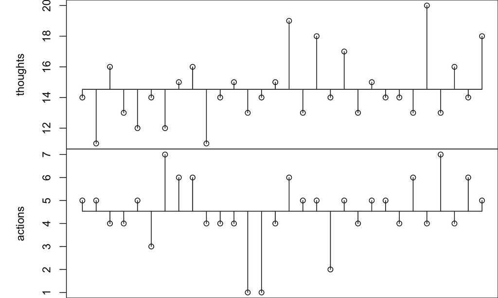

## \({SS}_{model}\)

And our sums of squares for both models.

\[{SS}_{model} = \sum{n_k(\bar{X}_k-\bar{X})^2}\]

```r
SS.model.tho = sum( n.cbt.tho*( m.cbt.tho - m.tho )^2,
                    n.bet.tho*( m.bet.tho - m.tho )^2,
                    n.con.tho*( m.con.tho - m.tho )^2 )

SS.model.act = sum( n.cbt.act*( m.cbt.act - m.act )^2,
                    n.bet.act*( m.bet.act - m.act )^2,
                    n.con.act*( m.con.act - m.act )^2 )
```

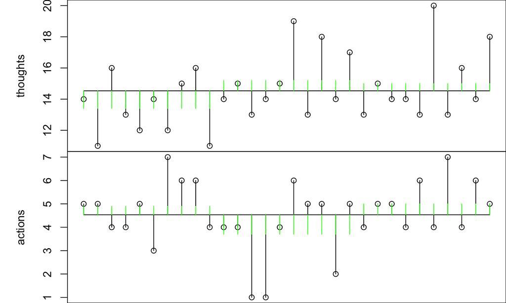

## \({SS}_{error}\)

\[{SS}_{error} = \sum{s_k^2(n_k-1)}\]

And finally the sums of squares for the errors are easy.

```r
SS.error.tho = SS.total.tho - SS.model.tho
SS.error.act = SS.total.act - SS.model.act
```

We will leave the the mean squares for what they are because we only need the sums of squares.

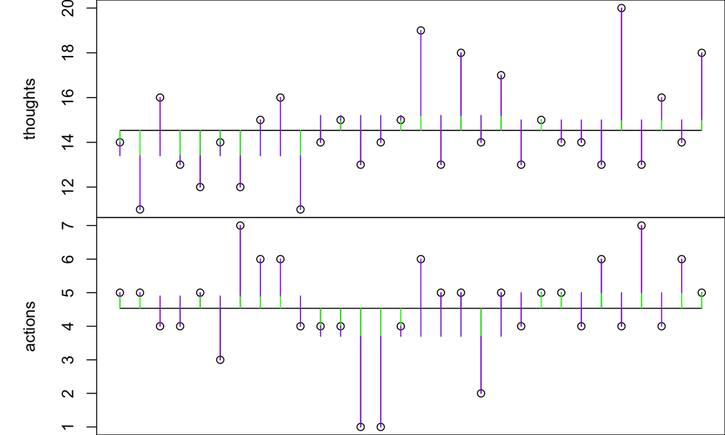

## Cross product

For the MANOVA we need the cross products (cross multiplications) of the two variates for the total, the model and the error. This is comparable to calculating the covariance for a correlation.

## \({CP}_{total}\)

\[{CP}_{total} = \sum_{i=1}^n \left( X_{i({DV}_1)} - \bar{X}_{grand({{DV}_1})} \right) \left( X_{i({DV}_2)} - \bar{X}_{grand({{DV}_2})} \right)\]

```r
CP.total = sum( (actions - m.act) * (thoughts - m.tho) )
```

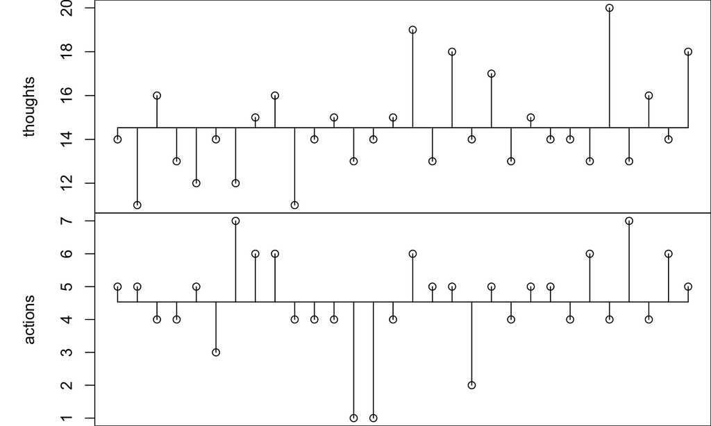

## \({CP}_{model}\)

\[{CP}_{model} = \sum_{grp=1}^k n_{grp} \left( \bar{X}_{grp({{DV}_1})} - \bar{X}_{grand({{DV}_1})} \right) \left(\bar{X}_{grp({{DV}_2})} - \bar{X}_{grand({{DV}_2})} \right)\]

```r
CP.model = n.cbt.tho * (m.cbt.tho - m.tho) * (m.cbt.act  - m.act) +
           n.bet.tho * (m.bet.tho - m.tho) * (m.bet.act  - m.act) +
           n.con.tho * (m.con.tho - m.tho) * (m.con.act  - m.act)
```

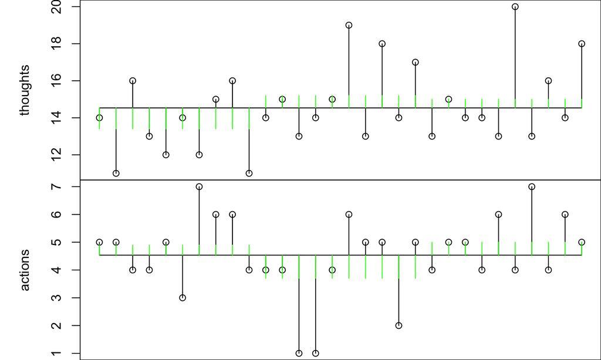

## \({CP}_{error}\)

\[{CP}_{error} = \sum_{i=1}^n \left(X_{i({{DV}_1})} - \bar{X}_{grp({{DV}_1})} \right) \left(X_{i({{DV}_2})} - \bar{X}_{(grp{{DV}_2})} \right)\]

```r
# And the easy way
CP.error = CP.total - CP.model
```

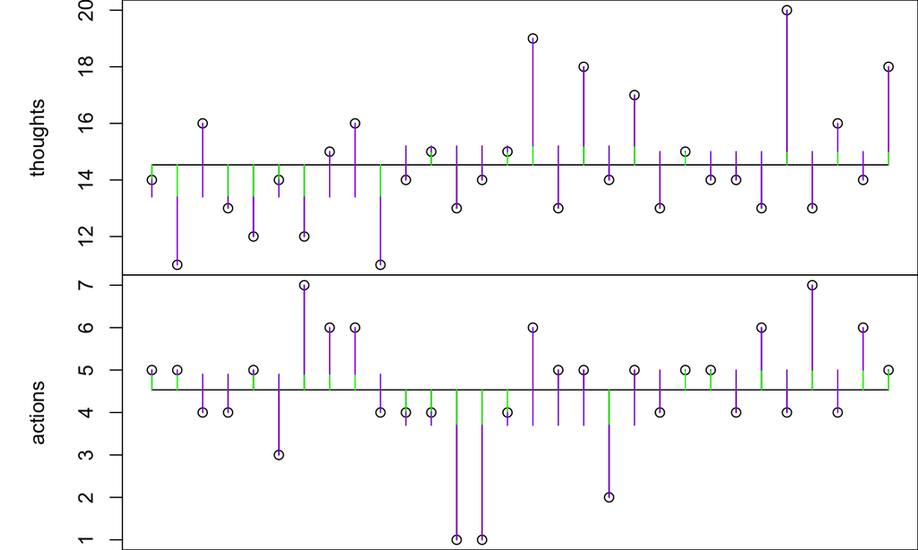

## SS cross product matrix

Now we have all the components to create the sums of squares cross product matrix. Creating a matrix in R is easy. We can use the `matrix()` function. We can define the values in the matrix using the `c()` function and we can define the dimentions, in our case 2x2.

## Total cross product matrix

\[T = \begin{pmatrix} {SS}_{T({DV}_1)} & {CP}_T \\ {CP}_T & {SS}_{T({DV}_2)} \end{pmatrix}\]

```r
# Assign total matrix to variable T
T = matrix(c(SS.total.act,CP.total,
             CP.total,SS.total.tho),2,2)
round(T, 2)
```

```
##       [,1]   [,2]
## [1,] 61.47   5.47
## [2,]  5.47 141.47
```

## Model cross product matrix

\[H = \begin{pmatrix} {SS}_{M({{DV}_1})} & {CP}_M \\ {CP}_M & {SS}_{M({DV}_2)} \end{pmatrix}\]

```r
# Assign model/hypothesis matrix to variable H
H = matrix(c(SS.model.act,CP.model,
             CP.model,SS.model.tho),2,2)
round(H, 2)
```

```
##       [,1]  [,2]
## [1,] 10.47 -7.53
## [2,] -7.53 19.47
```

## Error cross product matrix

\[E = \begin{pmatrix} {SS}_{E({DV}_1)} & {CP}_E \\ {CP}_E & {SS}_{E({DV}_2)} \end{pmatrix}\]

```r
# Assign error matrix to variable E
E = matrix(c(SS.error.act,CP.error,
             CP.error,SS.error.tho),2,2)
round(E, 0)
```

```
##      [,1] [,2]
## [1,]   51   13
## [2,]   13  122
```

## Multivariate signal to noise

Now in the same way we get the F ration in ANOVA by looking at the ratio of the variance in the model and the variance of the error, with MANOVA we have to look at the ratio of the hypothesis matrix H and the error matrix E. The problem is that you just can’t devide matrices. Bus you can multibply by the inverse to get to the devision of a matrix. This is said to be very hard but R makes this very easy for us.

We can use the `solve()` function to get the inverse of a matrix. U can use the `%*%` operator to multiply a matrix by an inverse matrix.

So let’s first calculate the inverse of the error matrix E and then multiply that with the hypothesis matrix H.

```r
# Create inverse E
E.inverse = solve(E)
round(E.inverse, 4)
```

```
##         [,1]    [,2]
## [1,]  0.0202 -0.0021
## [2,] -0.0021  0.0084
```

```r
# And multiply
HE.inverse = H %*% E.inverse
round(HE.inverse, 4)
```

```
##         [,1]    [,2]
## [1,]  0.2271 -0.0860
## [2,] -0.1936  0.1802
```

## Eigen values

```r
eigen.values = eigen(HE.inverse)$values
round(eigen.values, 3)
```

```
## [1] 0.335 0.073
```

## Test statistics

Finaly we can calculate the test statistic for our \(H_0\) hypothesis testing.

## Pillai-Barrtlett trace

> Pillai’s trace is the sum of the proportion of explained variance on the discriminant functions.

\[V = \sum_{i=1}^s \frac{\lambda_i}{1 + \lambda_i}\]

```r
P.B.trace = sum(eigen.values / (1 + eigen.values))
P.B.trace
```

```
## [1] 0.3184546
```

## Hotelling-Lawley trace

> The Hotelling–Lawley trace… …is simply the sum of the eigenvalues for each variate

\[T = \sum_{i=1}^s \lambda_i\]

```r
H.L.trace = sum(eigen.values)
H.L.trace
```

```
## [1] 0.4073352
```

## Wilks’s lambda

> Wilks’s lambda is the product of the unexplained variance

\[\Lambda = \prod_{i=1}^s \frac{1}{1 + \lambda_i}\]

```r
W.lambda = prod(1 / (1 + eigen.values))
W.lambda
```

```
## [1] 0.698509
```

## Roy’s largest root

> Roy’s largest root is the largest eigenvalue.

\[\Theta = \lambda_{largest}\]

```r
R.largest.root = max(eigen.values)
R.largest.root
```

```
## [1] 0.3347974
```

## Follow-up Analysis

- Single ANOVA’s
  - Contrasts
  - Posthoc
- Discriminant Analysis (Not part of this course)

## End

- [@shklinkenberg](https://twitter.com/shklinkenberg)
- [Klinkenberg](https://www.linkedin.com/in/sharonklinkenberg/)
- ln.AvU@grebneknilK.S
- ShKlinkenberg